# Iris Exploration

Julian Frattini

2023-11-08

```r
# tidyverse packages plus patchwork for figure assembly
library(tidyverse)
library(patchwork)

# machine learning libraries
library(caret)
library(nnet)
library(MLeval)

# decision tree libraries
library(rattle)
```

This file contains the analysis of the [Iris data](https://www.kaggle.com/datasets/uciml/iris).

## Data Loading

We load the Iris data from the included base R package `databases`.

```r
data(iris)
iris$Species <- as.factor(iris$Species)
head(iris)
```

```
##   Sepal.Length Sepal.Width Petal.Length Petal.Width Species
## 1          5.1         3.5          1.4         0.2  setosa
## 2          4.9         3.0          1.4         0.2  setosa
## 3          4.7         3.2          1.3         0.2  setosa
## 4          4.6         3.1          1.5         0.2  setosa
## 5          5.0         3.6          1.4         0.2  setosa
## 6          5.4         3.9          1.7         0.4  setosa
```

For an initial overview we visualize the distribution of the four input variables split by groups.

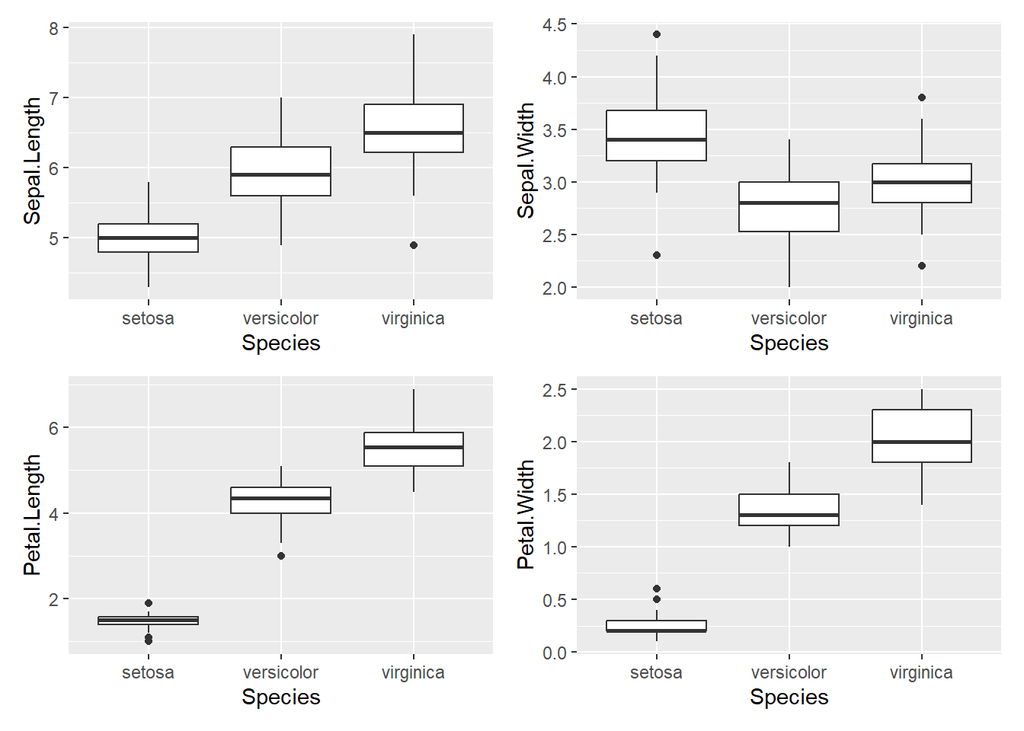

```r
vis.sepal.length <- ggplot(iris, aes(x=Species, y=Sepal.Length)) + geom_boxplot()
vis.sepal.width <- ggplot(iris, aes(x=Species, y=Sepal.Width)) + geom_boxplot()
vis.petal.length <- ggplot(iris, aes(x=Species, y=Petal.Length)) + geom_boxplot()
vis.petal.width <- ggplot(iris, aes(x=Species, y=Petal.Width)) + geom_boxplot()

(vis.sepal.length | vis.sepal.width) / (vis.petal.length | vis.petal.width)
```

## Model comparison

The response variable, `Species`, is a categorical variable with three levels, which limits the space of eligible methods. We try out both decision trees (`method="rpart`) and multinomial logistic regression (`method="multinom`). For evaluation, we define the training control to be a k-fold cross-validation.

```r
train_control <- trainControl(method="cv", number=5, repeats=3, savePredictions = TRUE)
```

### Decision tree

A decision tree determines conditions which split the data set into more pure subsets.

```r
fit.dtree <- train(Species ~ ., data=iris, method="rpart", trControl = train_control)
fit.dtree
```

```
## CART
##
## 150 samples
##   4 predictor
##   3 classes: 'setosa', 'versicolor', 'virginica'
##
## No pre-processing
## Resampling: Cross-Validated (5 fold)
## Summary of sample sizes: 120, 120, 120, 120, 120
## Resampling results across tuning parameters:
##
##   cp    Accuracy   Kappa
##   0.00  0.9200000  0.88
##   0.44  0.7666667  0.65
##   0.50  0.3333333  0.00
##
## Accuracy was used to select the optimal model using the largest value.
## The final value used for the model was cp = 0.
```

We can use the `rattle` library to visualize the decision tree.

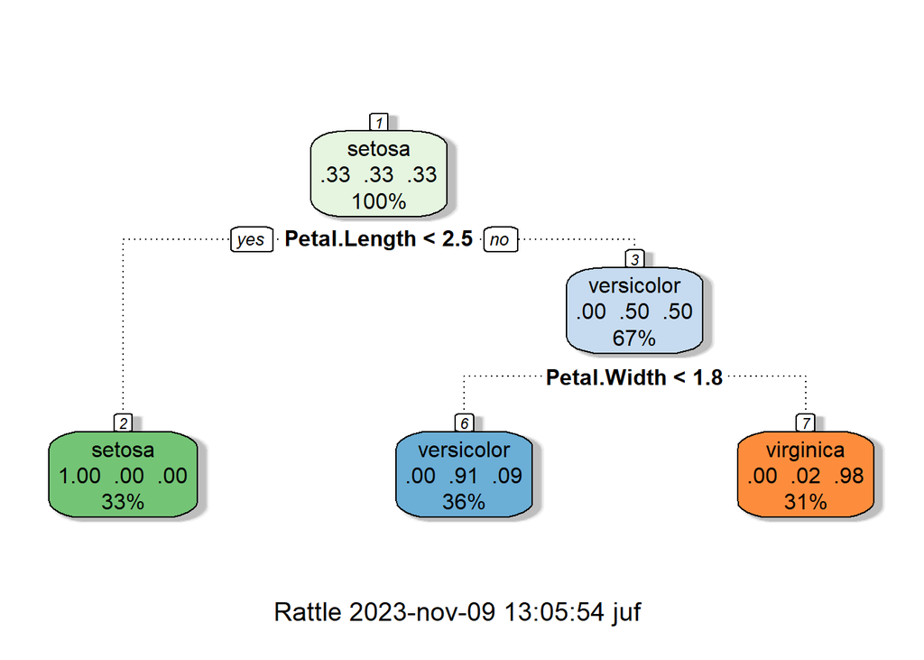

```r
fancyRpartPlot(fit.dtree$finalModel)
```

### Multinomial Logistic Regression

Multinomial logistic regression determines regression functions for each level of the response variable (minus the reference value).

```r
fit.multinom <- caret::train(Species~., data=iris, trControl=train_control, method="multinom")
summary(fit.multinom)
```

[output not shown]

The model exhibits a sufficient accuracy of $>95%$.

```r
fit.multinom
```

```
## Penalized Multinomial Regression
##
## 150 samples
##   4 predictor
##   3 classes: 'setosa', 'versicolor', 'virginica'
##
## No pre-processing
## Resampling: Cross-Validated (5 fold)
## Summary of sample sizes: 120, 120, 120, 120, 120
## Resampling results across tuning parameters:
##
##   decay  Accuracy   Kappa
##   0e+00  0.9733333  0.96
##   1e-04  0.9733333  0.96
##   1e-01  0.9666667  0.95
##
## Accuracy was used to select the optimal model using the largest value.
## The final value used for the model was decay = 1e-04.
```

The confusion matrix shows that the levels `setosa` and `versicolor` are easy to distinguish, but there are still slight misclassifications between `versicolor` and `virginica`.

```r
confusionMatrix(fit.multinom)
```

```
## Cross-Validated (5 fold) Confusion Matrix
##
## (entries are percentual average cell counts across resamples)
##
##             Reference
## Prediction   setosa versicolor virginica
##   setosa       33.3        0.0       0.0
##   versicolor    0.0       32.0       1.3
##   virginica     0.0        1.3      32.0
##
##  Accuracy (average) : 0.9733
```

To understand the influence of each of the four predictors on the response variable, we visualize the coefficients of the covariates similar to https://rpubs.com/yanliu/viz_multinomial_regression. Firstly, we extract the mean and standard error from the trained final model.

```r
coef.matrix <- coef(fit.multinom$finalModel)
coefs <- data.frame(Category = row.names(coef.matrix), coef.matrix)

stderr.matrix <- summary(fit.multinom$finalModel)$standard.errors
stderrs <- data.frame(Category = row.names(stderr.matrix), stderr.matrix)

params.coef <- coefs %>%
  pivot_longer(cols=c("X.Intercept.", "Sepal.Length", "Sepal.Width", "Petal.Length", "Petal.Width"),
             names_to='Covariate', values_to = "estimate")

params.stderr <- stderrs %>%
  pivot_longer(cols=c("X.Intercept.", "Sepal.Length", "Sepal.Width", "Petal.Length", "Petal.Width"),
             names_to='Covariate', values_to = "stderr")

params <- params.coef %>%
  full_join(params.stderr, by=c('Category', 'Covariate')) %>%
  mutate(
    lower = estimate-stderr,
    upper = estimate+stderr
  )
```

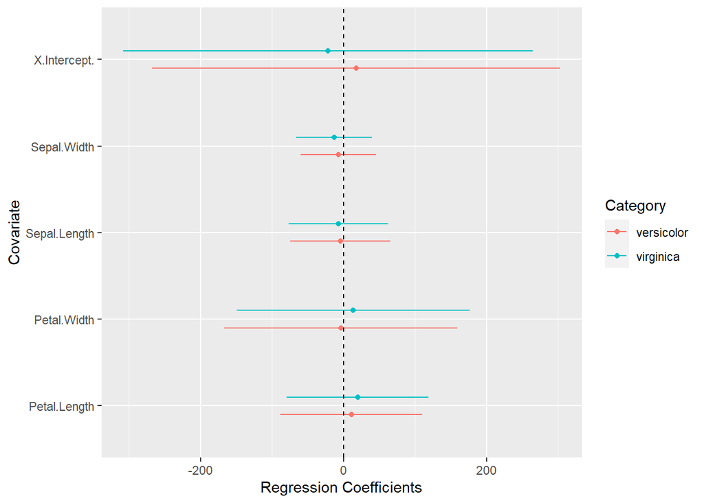

```r
pos <- position_nudge(y = ifelse(params$Category == "versicolor", -0.1, 0.1))

params %>%
  ggplot(aes(y=Covariate, x=estimate, color=Category)) +
    geom_point(position = pos) +
    geom_linerange(aes(xmin = lower, xmax = upper), position = pos) +
    geom_vline(xintercept=0, linetype="dashed") +
    scale_x_continuous(name ="Regression Coefficients")
```

### Neural Network

```r
fit.nnet <- caret::train(Species~., data=iris, trControl=train_control, method="nnet")
```

```r
fit.nnet
```

```
## Neural Network
##
## 150 samples
##   4 predictor
##   3 classes: 'setosa', 'versicolor', 'virginica'
##
## No pre-processing
## Resampling: Cross-Validated (5 fold)
## Summary of sample sizes: 120, 120, 120, 120, 120
## Resampling results across tuning parameters:
##
##   size  decay  Accuracy   Kappa
##   1     0e+00  0.7266667  0.59
##   1     1e-04  0.8733333  0.81
##   1     1e-01  0.9600000  0.94
##   3     0e+00  0.8666667  0.80
##   3     1e-04  0.9666667  0.95
##   3     1e-01  0.9666667  0.95
##   5     0e+00  0.8333333  0.75
##   5     1e-04  0.9600000  0.94
##   5     1e-01  0.9666667  0.95
##
## Accuracy was used to select the optimal model using the largest value.
## The final values used for the model were size = 3 and decay = 0.1.
```

### Model comparison

Finally, we assemble the results of all models to compare their accuracy.

```r
ensambleResults <- resamples(
  list(
    MNom = fit.multinom,
    DTree = fit.dtree,
    NNet = fit.nnet))
summary(ensambleResults)
```

```
##
## Call:
## summary.resamples(object = ensambleResults)
##
## Models: MNom, DTree, NNet
## Number of resamples: 5
##
## Accuracy
##       Min.   1st Qu. Median      Mean   3rd Qu.      Max. NA's
## MNom   0.9 0.9666667    1.0 0.9733333 1.0000000 1.0000000    0
## DTree  0.9 0.9000000    0.9 0.9200000 0.9333333 0.9666667    0
## NNet   0.9 0.9333333    1.0 0.9666667 1.0000000 1.0000000    0
##
## Kappa
##       Min. 1st Qu. Median Mean 3rd Qu. Max. NA's
## MNom  0.85    0.95   1.00 0.96     1.0 1.00    0
## DTree 0.85    0.85   0.85 0.88     0.9 0.95    0
## NNet  0.85    0.90   1.00 0.95     1.0 1.00    0
```

We can visualize the ensable to compare their accuracy.

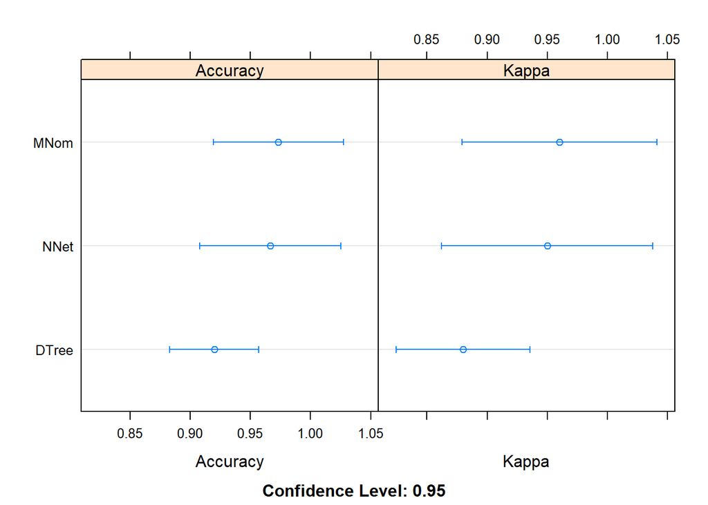

```r
lattice::dotplot(ensambleResults)
```